# Introduction to R programming for data science – day 6

Medical University of Innsbruck, Austria

## Read and write text files

## Reading tables with *read.table*

Plain text files in table format can be loaded into R as data.frames using the function read.table

```r
read.table(file,             # Input file
    header = FALSE,          # Use first row as column names?
    sep = "",                # Column separator in the input file
    row.names = 1,           # Column containing the row names
    nrows = -1,              # Number of rows to be read
    skip = 0,                # Number of rows to be skipped
    check.names = TRUE,      # Check and fix column names?
                             # (e.g. "123-A" --> "X123.A")
    stringsAsFactors = FALSE, # Save strings as factors?
    ...)
```

Once you load a table into R, you can check how it looks like using head and tail, and check its dimensions with dim

## Reading tables with *read.delim* and *read.csv*

Depending on the column separator in the input file, read.delim and read.csv can be also used to import files in table format

```r
read.delim(file,
      header = TRUE,
      sep = "\t", ...)

read.csv(file,
      header = TRUE,
      sep = ",", ...)
```

The are both based on the read.table function, but they use different paremeter settings (e.g. “sep”)

## Save data in plain text files

Data.frames and matrices can be saved into text files

```r
( DF <- data.frame(name=c("Mary", "John", "Lisa"),
  age=c(19, 30, 20),
  city=c("New York", "Seattle", "New York")) )
```

```
##   name age     city
## 1 Mary  19 New York
## 2 John  30  Seattle
## 3 Lisa  20 New York
```

```r
write.table(DF,
  quote = FALSE,
  sep = "\t",
  row.names = FALSE,
  col.names = TRUE,
  file =  "../Data/Day3_Friends_table.txt")
```

## Read and write Excel files

## The *xlsx* package

The [xlsx](https://cran.r-project.org/web/packages/xlsx/index.html) package provides R functions to handle Excel files (97/2000/XP/2003/2007 formats)

It is available on CRAN and can be installed from the “Packages” window or by executing

```r
install.packages("xlsx")
```

Once installed, it can be loaded with library, which is the function to load (installed) R packages into R

```r
library("xlsx"")
```

## Read Excel files

The read.xlsx function from the [xlsx](https://cran.r-project.org/web/packages/xlsx/index.html) package can be used to read Excel files

```r
read.xlsx(file,           # File to be read
  sheetIndex,             # Number of the sheet to be read
  sheetName = NULL,       # Character indicating the sheet name
  startRow = NULL,        # First row to be read
  endRow = NULL,          # Last row to be read
  header = TRUE,          # Does the first row contain column names?
  keepFormulas = FALSE,   # Display formulae (instead of results)?
  ...)
```

## Write Excel files

The write.xlsx function from the [xlsx](https://cran.r-project.org/web/packages/xlsx/index.html) package can be used to write Excel files

```r
write.xlsx(x,             # Table to be written
  file,                   # Path to the output file
  sheetName = "Sheet1",   # Character indicating the sheet name
  col.names = TRUE,       # Write column names?
  row.names = TRUE,       # Write row names?
  ...)
```

## Excel and gene names

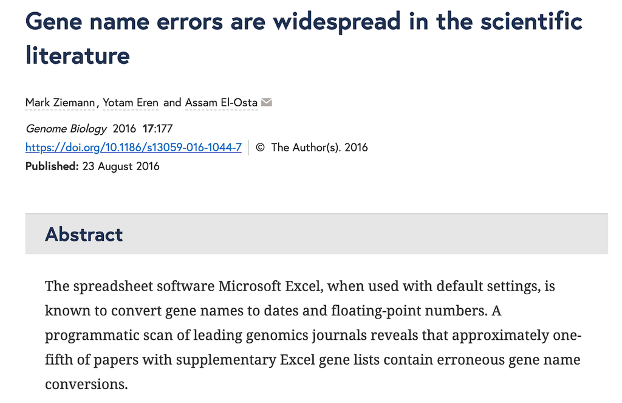

## The *readr* package

[figure not shown]

The [readr](https://readr.tidyverse.org/) package from [tidyverse](https://www.tidyverse.org/) provides functions  
to read files with different formats:

- read_csv: comma separated (CSV) files
- read_tsv: tab separated files
- read_delim: general delimited files
- read_fwf: fixed width files
- read_table: tabular files where columns are separated by white-space
- read_log: web log files